# Sprawozdanie

Olga Sieradzan, Justyna Sarkowicz, Weronika Duda, Amelia Madej, Aleksandra Węgrzyn

2025-01-09

# Wprowadzenie

Umiejętność przewidywania zachowań spółek na giełdzie oraz identyfikacji spadków i wzrostów jest kluczową kompetencją współczesnych algorytmów działających na giełdzie. Szeroka gama narzędzi wspomaga maklerów w podejmowaniu decyzji o środkach, którymi obracają. W tej dziedzinie niezwykle pomocne okazują się sieci neuronowe, które są szeroko wykorzystywane do prognozowania cen na giełdzie.

W ramach badania postanowiono zbadać działanie rekurencyjnych sieci neuronowych (LSTM) na danych dotyczących notowań giełdowych spółki Microsoft od roku 2010. Zbiór treningowy stanowi 80% danych, natomiast działanie modelu jest testowane na ostatnich 20% danych.

Modele LSTM zależą od dużej liczby parametrów, a ich dobór ma istotny wpływ na wyniki. W badaniu postanowiono zbadać wpływ 5 różnych parametrów, testując przy każdym z nich 4 różne wartości.

Sprawdzanymi parametrami są;

- **Funkcja aktywacji** - mechanizm który decyduje o tym jakie informacje mają zostać podane dalej w sieci, a które mają być zapomniane.

  *Badane wartości: f.liniowa, f.sigmondalna, f.relu, f.tangens hiberboliczny(tanh)*
- **Rozmiar partii** - liczba próbek, które są przetważane przez model w jednym przebiegu podczas uczenia. Wielkość partii znacząco wpływa na aktualizacje wag w trakcie treningu.

  *Badane wartości: 16, 32, 64, 128*
- **Liczba wartstw** - liczba poziomów przez które przechodzą dane w trakcie prztwarzania. Im wiecej takich warstw tym głębsze są sieci.

  *Badane wartości: 2, 3, 4, 5*
- **Liczba neuronów** - ilość neuronów w pojedyńczej warstwie. W neuronie przetważane są informacje sieci za pomocą wybranych funkcji aktywacyjnych i przekazywane dalej.

  *Badane wartości: 50, 100, 150, 200*
- **Optymalizator** - algorytm działający w celu optymalizacji wag sieci aby minimaliozwać błąd predykcji.

  *Badane wartości: Adam, RMSprop, SGD, Adagrad*

# Opis danych i metodyki

Do predyckji cen firmy Microsoft wbrano model LSTM (Long Short-Term Memory), ponieważ modele LSTM są wysoce przydatne w modelowaniu danych sekwencyjnych czyli np. szeregów czasowych, którym są odczyty cen zamknięcia z giełdy.

W celu użycia tego modelu, przeprowadzona została normalizacja danych do zakresu od 0 do 1, za pomocą wzoru
$$X' = \frac{X - \min(X)}{\max(X) - \min(X)}$$

Dodatkowo, dane potrzebowały podziału na sekwencje i odpowiadających im wartości docelowych. Na przykład dla zbioru [1,2,3,4,5], tworzymy dwa podzbiory [1,2,3] ,[2,3,4] oraz odpowiadające im etykiety, [4] i [5].

Firma Microsoft została wybrana do badania ze względu na popularność spółki (przynależnośc do wielkiej piątki), i co za tym idzie, dużą ilość publikacji w związku z tą spółką.

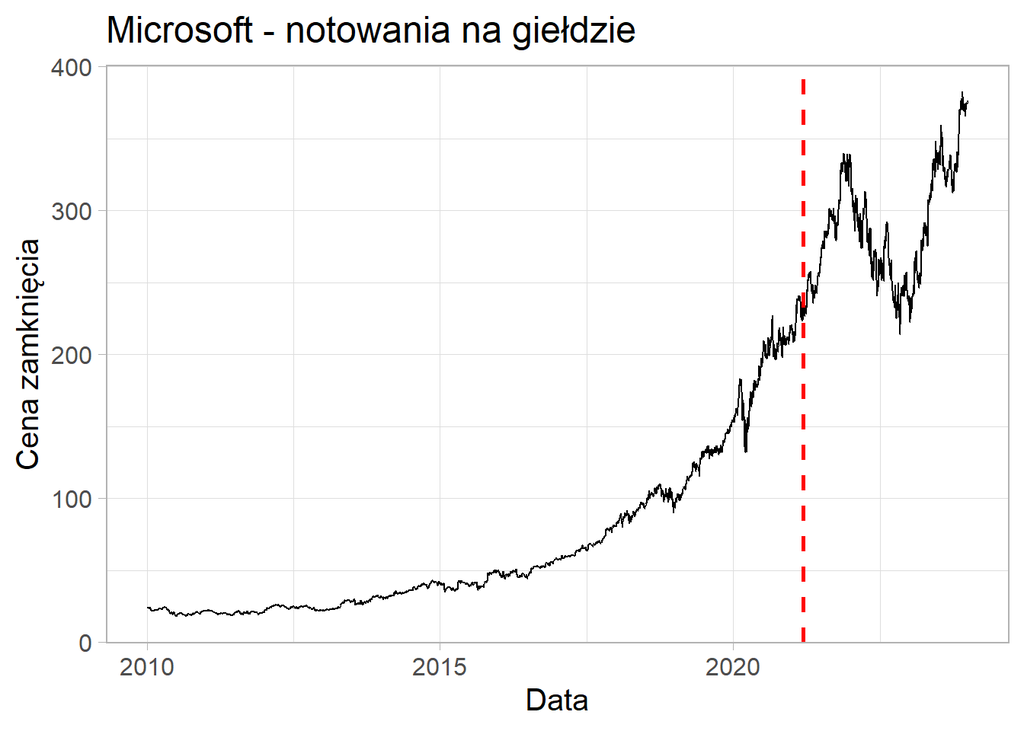

Na wykresie można zauważyć dane na których działano w badaniu. Czerwona linia zaznacza 80% danych, czyli po lewej stronie lini jest zbiór treningowy, natomiast po prawej stronie lini widac zbiór testowy.

# Wyniki

Łącznie przeprowadzono 100 prognozowań, 5 razy dla każdego zestawu parametrów. Badano wpływ 5 różnych parametrów. W sprawozdaniu pokazywany będzie zestaw wykresów dla jednen z 5 prób przeprowadzonych dla wszytskich parametrów, w celu zaoszczędzenia miejsca i długości sprawozdania. Dostęp do wykresów dla wszytskich prób przeprowadzonych w ramach badania jest w folderze ‘plots’, dołączonym do sprawozdania.

## Funkcja aktywacyjna

Na poniższych wykresach zaprezentowano wyniki dla 4 badanych funkcji aktywacyjnych.

Pozostałe parametry pozostają stałe:

- liczba neuronów = 20
- optymalizator = Adam
- rozmiar partii = 16
- liczba warstw = 3

**Funkcja liniowa**

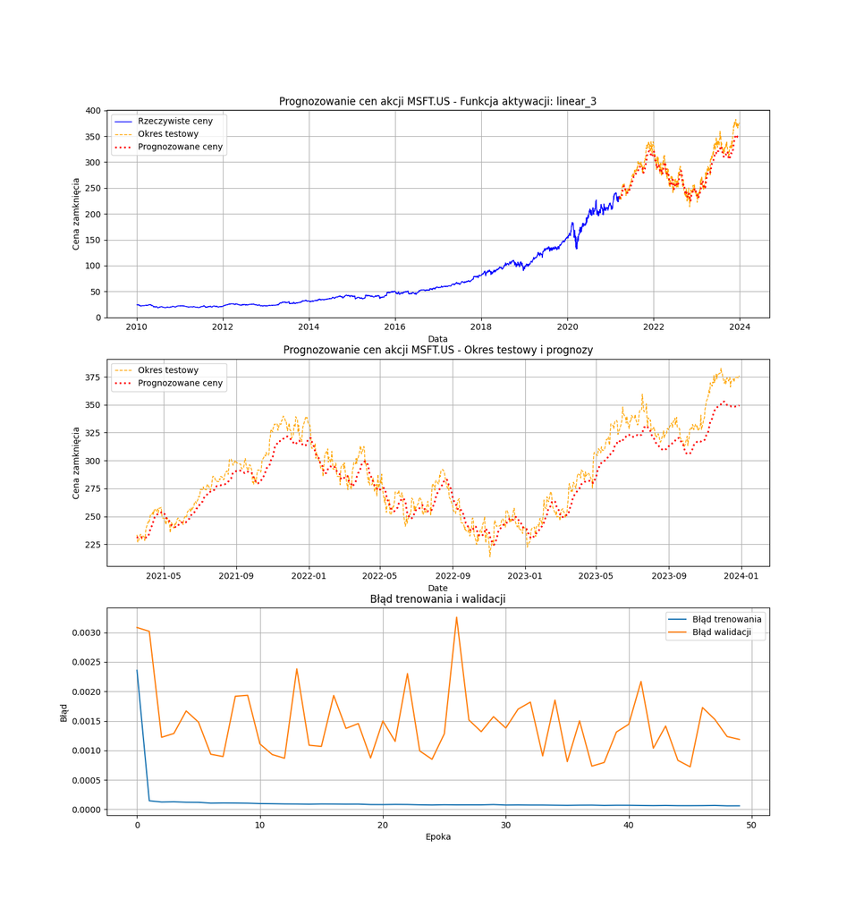

**Funkcja relu**

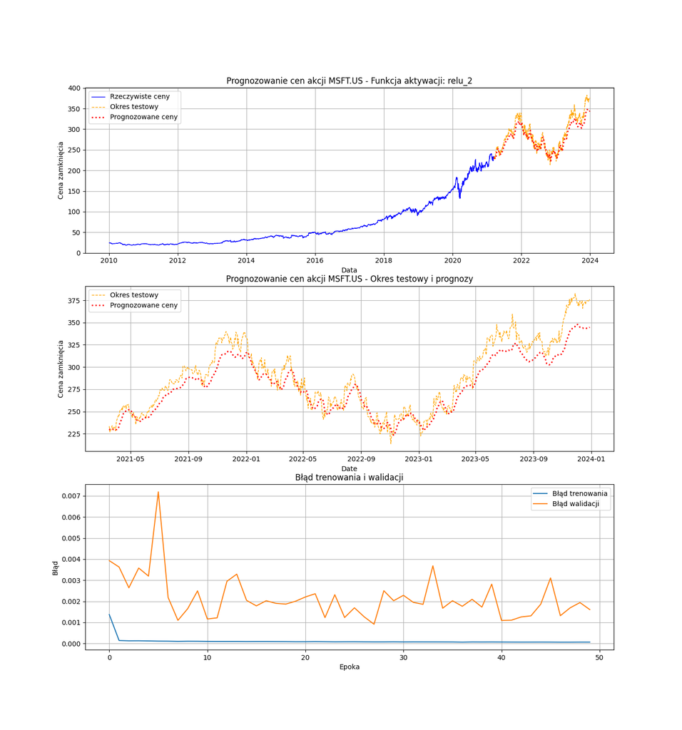

**Funkcja sigmoindalna**

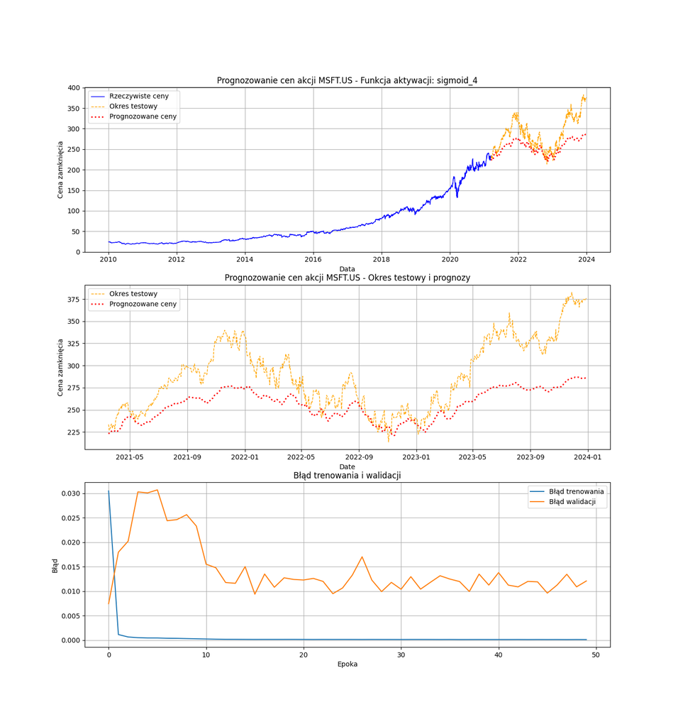

**Funkcja tangenshiperboliczny**

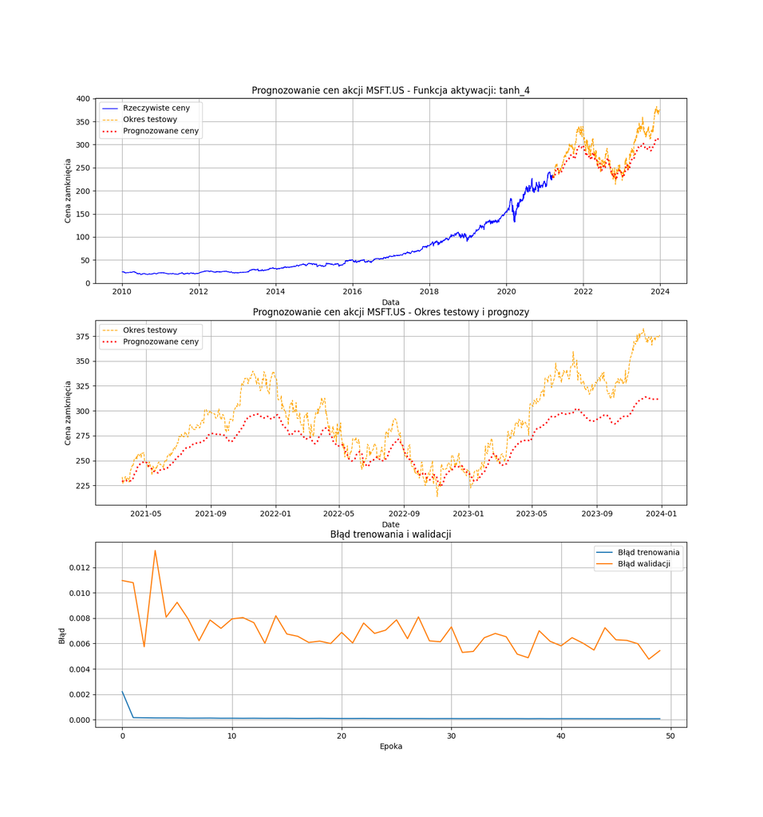

Najniższy błąd walidacji wyszedł w przypadku funkcji liniowej oraz funkcji relu (~ 0.002), chociaż warto wspomnieć że w przypadku dwóch prób, które mozna znaleśc w folderze plots, funckja relu zaprognozowała same zera.

Słabym dopasowaniem cechuje się funkcja sigmoindalna, gdzie błąd walidacji sięgnał 0.03. W wynikach dla tej funkcji można zauważyć zdecydowne niedoszacowanie w momencie w którym spółka microsoft osiągała wyższe ceny na giełdzie. Podobnie jest w przypadku użycia funkcji tanh.

## Rozmiar partii

Na ponizszych wykresach, zaprezentowano wyniki dla zwiekszającej się ilości próbek w partii.

Pozostałe parametry pozostają stałe:

- liczba neuronów = 20
- optymalizator = Adam
- funkcja aktywacji = f.liniowa
- liczba warstw = 3

**16 próbek**

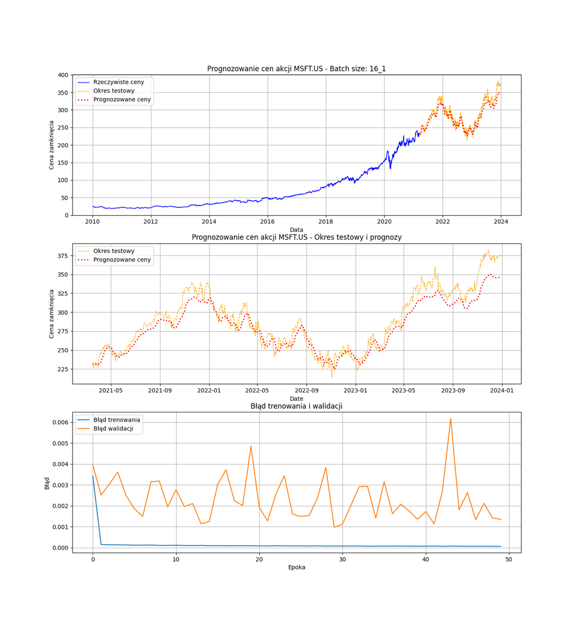

**32 próbki**

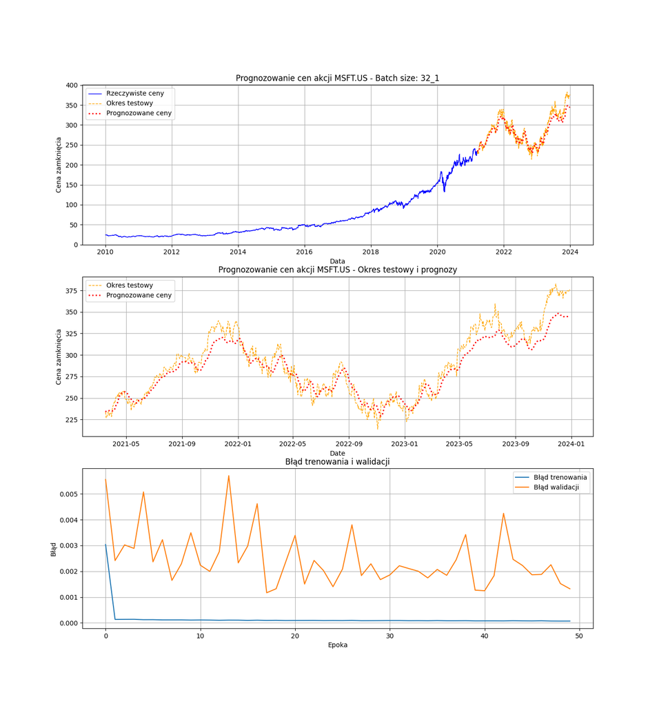

**64 próbki**

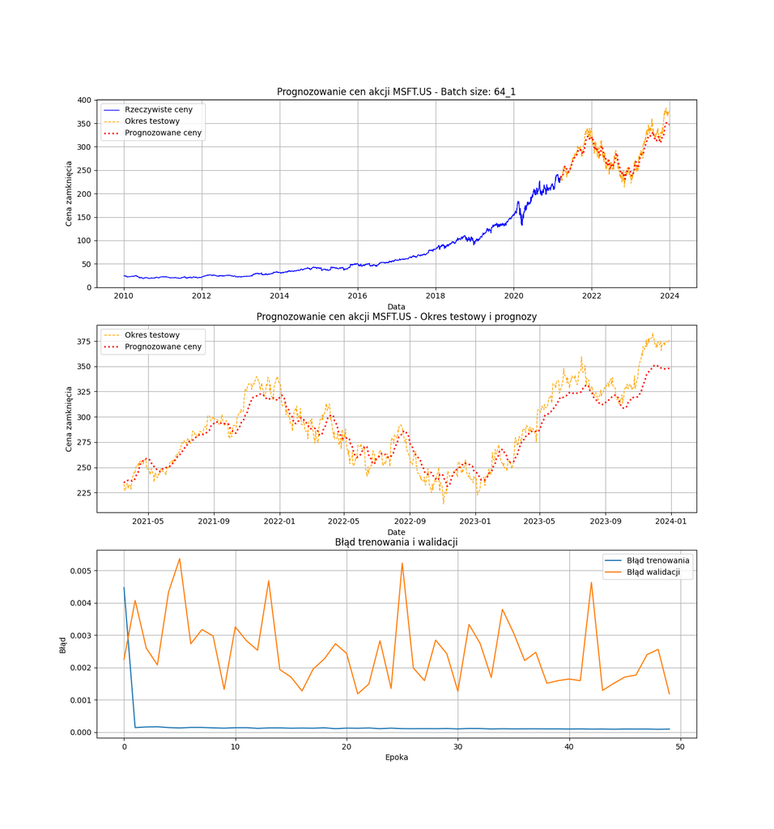

**128 próbek**

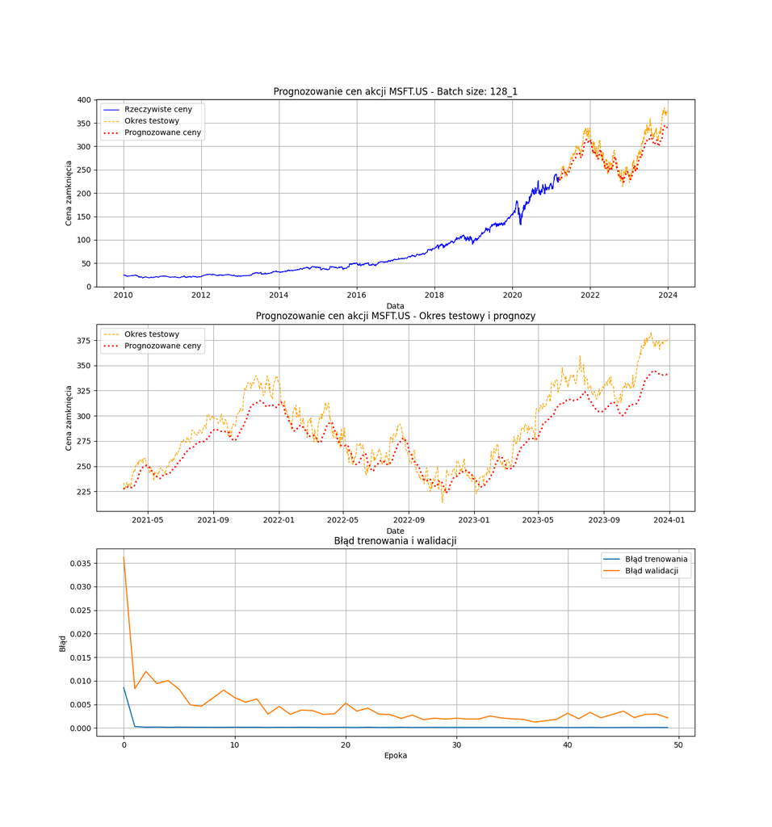

Dla pierwszych trzech badanych rozmiarów partii, różnica nie wydaje się znacząca. Błędy walidacji są bardzo podobne i oscylują dookoła 0.003.

Natomiast zwiekszenie romiaru partii do 128 próbek, wprowadza pogorszenie się wyników i zwiekszenie błędu walidacji.

## Liczba wartsw

Na poniższych wykresach zaprzentowano wykresy dla zwiekszającej się ilości wartw w zbudowanym modelu.

Pozostałe parametry pozostają stałe:

- liczba neuronów = 20
- optymalizator = Adam
- funkcja aktywacji = f.liniowa
- rozmiar partii = 16

**2 warstwy**

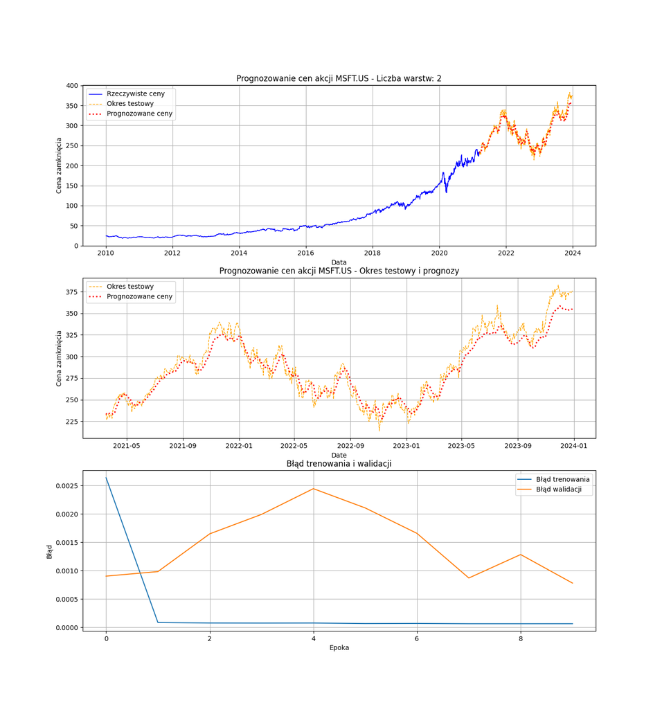

**3 warstwy**

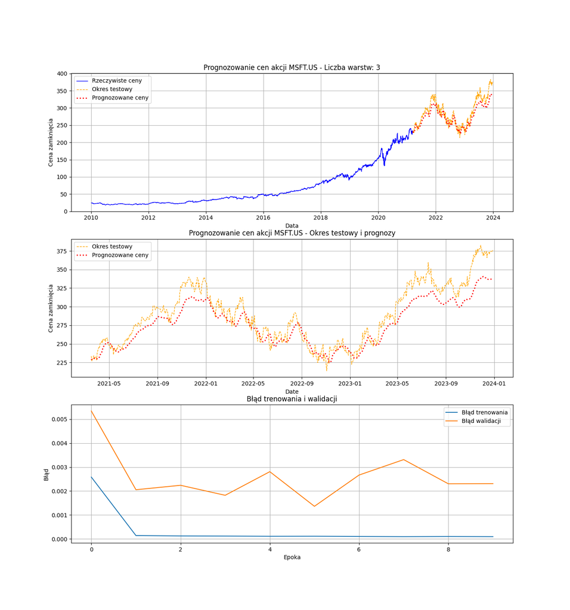

**4 warstwy**

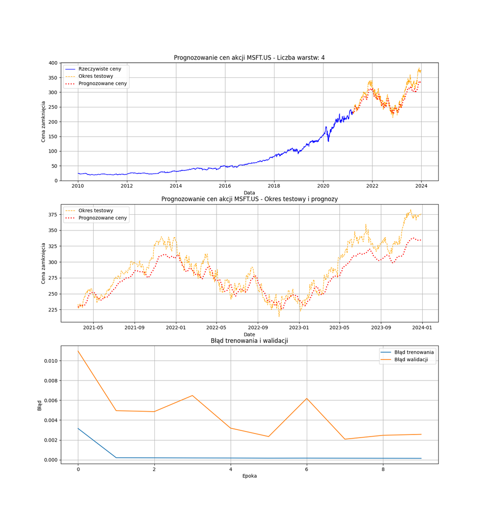

**5 warstw**

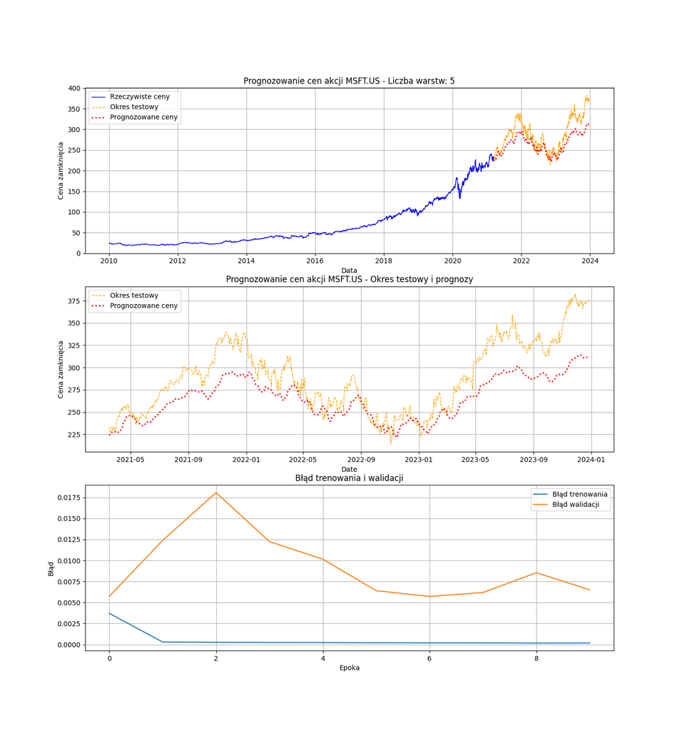

Na wykresach można zauważyć zależność , że im wiecej wartstw tym predykcja minimalnie gorsza. Badacze nie spodziewali sie takiej zależności.